# Final Project Data Analysis for Business -

### CLUSTERS ANALYSIS AND CONCLUSION

#### Cluster Analysis

Since K-means represents in a clearer way the clusters without “overlapping” (problem that we encountered adopting the hierarchical method), we decided to consider the latter for our final analysis.

Initially, we analyze each cluster by plotting the mean values of the features used to construct the clusters. This allows us to understand the characteristic profiles of each cluster based on the key attributes that define them.

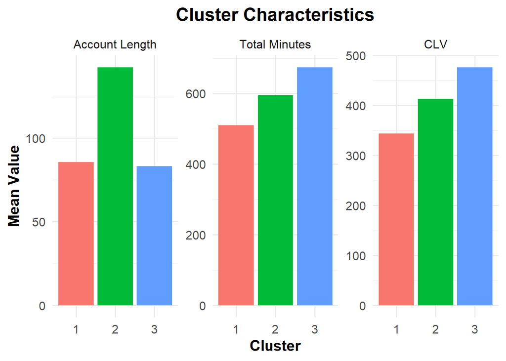

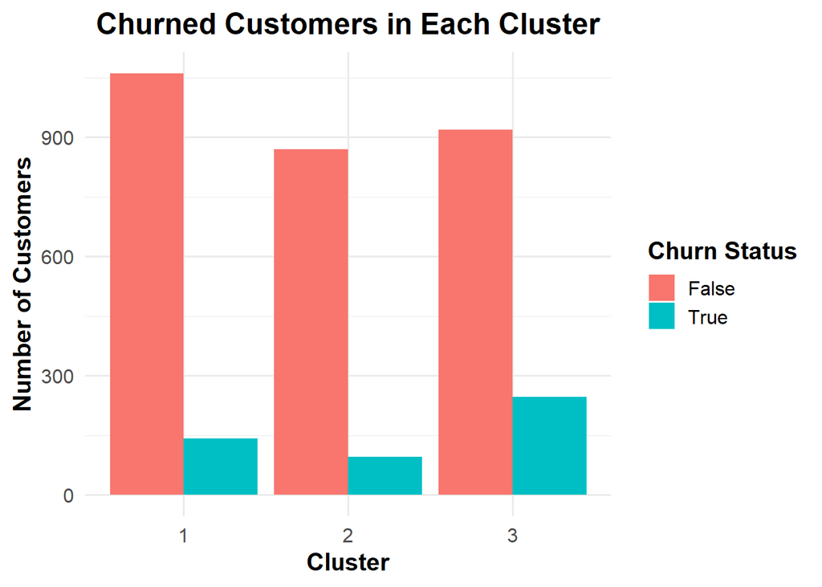

The bar plot illustrates the number of churned (True) and non-churned (False) customers across various clusters, revealing significant insights into customer retention. Overall, the three clusters are fairly equally distributed in terms of customer count. Notably, cluster 3 stands out with the highest number of churned customers, despite having the highest Customer Lifetime Value (CLV). This discrepancy suggests that Telecom is struggling to retain its most valuable customers, likely due to dissatisfaction or unmet expectations.

To address this, Telecom should implement targeted retention strategies, such as personalized offers and improved customer service, to reduce churn and maximize the value of these high-CLV customers. This analysis highlights the critical need to focus on clusters with high churn rates and high CLV for targeted retention strategies, enabling the company to optimize promotional efforts and reduce costs. By implementing focused promotional campaigns and retention initiatives specifically for cluster 3, Telecom can effectively retain its most valuable customers, enhance overall customer satisfaction, and ultimately improve profitability by reducing churn among high-value segments.